# HTML5

New features:

- multimedia: tab for <audio> and <video>
- websocket;
- canvas;
- ...

## HTML5 gym

Default browser in Android (less than 4.4) uses "webkit" engine which is as same as the one in google chrome. In other words, Google chrome is the best choice to use to test HTML5 codes we had written.

However, the Android browser does not support all the new HTML5 functions; something would be wrong while testing HTML5 codes. Use

tools -> JavaScript Console or "Shift + Control + j" to activate the debug function.

## Android 4.4(KitKat): Progress about Webview

From this release, Chromium 30 is the web engine for the WebView native widget which, owns:

- Support for remote debugging;
- Support for new HTML5 features: Web Sockets, Web worker, IndexedDB, Animation Timing API, CSS3 Flexbox etc;
- Better performance.

But still not support: **WebGL, WebRTC, WebAudio, FullScreen and Form validation**.

## Note

Web-based Real-Time peer-peer communication (**WebRTC**) is the one of the new supported fonction for google chrome but not for Android browser, even the new kit-kate browser. Maybe someday, it will.

RTC Codes or visit the site: http://diffusion.cgu.edu.tw/android/RTCdemo.html

<form><input id="snapshot" value="Say Cheese" type="button"></form>  
<video autoplay="autoplay"></video><br>  
<canvas id="canvas" width="600" height="800"></canvas>  
<script type="text/javascript">  
var onFailSoHard = function(e){  
console.log('failed',e);  
}  
window.URL = window.URL || window.webkitURL ;  
navigator.getUserMedia = navigator.getUserMedia || navigator.webkitGetUserMedia;  
var video = document.querySelector('video');  
if(navigator.getUserMedia){  
navigator.getUserMedia({video: true},function(stream) {  
video.src = window.URL.createObjectURL(stream);  
},onFailSoHard);  
}  
document.getElementById('snapshot').onclick = function() {  
var canvas = document.getElementById('canvas');  
var ctx = canvas.getContext('2d');  
ctx.drawImage(video,0,0);  
}  
</script>

## jQuery and jQuery Mobile

Ajax library for Mobile devices

## Demo Template

<head>  
<meta name="viewport" content="user-scalable=no, initial-scale=1, width=device-width, height=device-height" />  
<link rel="stylesheet" href="css/jquery.mobile-1.3.2.min.css" />  
<script src="js/jquery-2.0.3.min.js"></script>  
<script src="js/jquery.mobile-1.3.2.min.js"></script>  
</head>  
<body>  
<div data-role="page">  
<div data-role="header">...</div>  
<div data-role="content">  
...  
</div>  
<div data-role="footer">...</div>  
</div>  
</body>

<div data-role="page">  
<div data-role="header">  
<h1> jQuery Mobile Demo</h1>  
</div>  
<div data-role="collapsible-set">  
<div data-role="collapsible">  
<h3> How to use this distro?</h3>  
<p>  
<span style="color: #663300; font-weight: bold;">Answer: </span> since this distro is designed as ready-to-boot state, only  
change the boot priority to CDROM, USB or net options in BIOS boot setting and reboot machine again.  
</p>  
</div>  
<div data-role="collapsible">  
...  
</div>  
<div data-role="collapsible">  
...  
</div>  
</div>  
<div data-role="footer">  
<h1>Diffusion</h1>  
</div>  
</div>

## Result

[figure not shown]

## Result

[figure not shown]

## CoffeeScript

a little language which do help to compiles into JavaScript

## BMI.coffee

```
calcBMI = (height, weight) -> weight/(height*0.01)/(height*0.01)
```

## Compile to BMI.js

```
shell > coffee -o js  --compile BMI.coffee
shell > cat js/BMI.js
(function() {
  var calcBMI;

  calcBMI = function(height, weight) {
    return weight / (height*0.01) / (height*0.01);
  };

}).call(this);
```

# Typical command for Canvas

New feature of HTML5 for creating on-line picture:

<script type="text/javascript">  
window.onload = function {  
var a_canvas = $("a_canvas");>  
var context = a_canvas.getContext("2d");  
...  
}  
</script>  
<body>  
<canvas id="a_canvas" style="width:100%; height:100%"></canvas>  
</body>  
**This creates a canvas as follows:**

(0,0) -------------------> (0,*x*)  
| |  
| |  
| |  
| |  
v v  
(0,*y*) ------------------> (*x*,*y*)

## Poly-line

make a poly-line, (x0,y0) to (x1,y1), ...:  
context.beginPath();  
context.moveTo(x0,y0)  
context.lineTo(x1,y1);  
...  
context.closePath();  
context.strokeStyle="red";  
context.stroke();

## Simple Pictures

**Circle**: $(x,y)=(r \cos t,r \sin t)$

var dt =1;  
var pi = Math.PI;  
context.moveTo(230,200)  
for (var i=0; i<360+1; i++){  
var t = -i\*dt\*pi/180  
var x= 200+30\*(Math.cos(t));  
var y= 200+30\*(Math.sin(t));  
context.lineTo(x,y);  
}

**Cardiac** $r=a+b \cos t$

var dt =1;  
var pi = Math.PI;  
context.moveTo(275,200)  
for (var i=0; i<360+1; i++){  
var t = -i*dt*pi/180  
var x= 200+30*(1+1.5*Math.cos(t))*(Math.cos(t));  
var y= 200+30*(1+1.5*Math.cos(t))*(Math.sin(t));  
context.lineTo(x,y);  
}

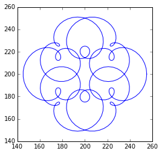

```python
import pylab as plt
import numpy as np

t=np.linspace(0,2*np.pi,400)

figsize(4,4)
plt.plot(200+30*(cos(t)+cos(7*t)/2+cos(17*t)/3),200+30*(sin(t)+sin(7*t)/2+sin(17*t)/3))
```

# Interesting picture (above)

$$(x,y)=(200+30(\cos(t)+\cos(7t)/2+\cos(17t)/3),200+30(\sin t+\sin(7t)/2+\sin(17t)/3)$$

context.beginPath();  
var x0=200+30*(1+1/2+1/3)  
context.moveTo(x0,200)  
var pi = Math.PI;  
for (var i=0; i<300+1; i++){  
var t = i*dt/30*pi/10;  
var x= 200+30*(Math.cos(t)+Math.cos(7*t)/2+Math.cos(17*t)/3);  
var y= 200+30*(Math.sin(t)+Math.sin(7*t)/2+Math.sin(17*t)/3);  
context.lineTo(x,y);  
}  
context.closePath();  
context.strokeStyle="red";  
context.stroke();

## Animation of Canvas

Just play the frame1, clear display, play frame2, clear, and so on.

[figure not shown]

```python
from IPython.display import HTML
```

```python
canvas="""
<canvas id="myCanvas" width="100" height="100"></canvas>
"""
```

```python
JSCode="""
<script>
    var width = 100,
    height = 100,
    frames = 4,
    currentFrame = 0,

    canvas = document.getElementById("myCanvas");
    ctx = canvas.getContext("2d");
    image = new Image()
    image.src = 'imgs/sprite.png';

    var draw = function(){
        ctx.clearRect(0, 0, width, height);
        ctx.drawImage(image, 0, height * currentFrame, width, height, 0, 0, width, height);

        if (currentFrame == frames) {
            currentFrame = 0;
        } else {
            currentFrame++;
        }
    }
    setInterval(draw, 1000/20);
</script>
"""
```

```python
HTML(canvas+JSCode)
```

[interactive chart not shown]

## Practice

Make a equilateral triangle by **canvas** tag.

# JSON Data Introduction

1. create file at which json data are stored:

   {"attendants":[

   ```
    {
        "seqNumber":"B0102010",
        "scores": {
            "MWC":"1",
            "Tutorial":"1",
            "Final":"0"
        }
    },
    {
        "seqNumber":"B0141037",
        "scores": {
            "MWC":"0",
            "Tutorial":"1",
            "Final":"0"
        }
    }
   ```

   }

i.e.

[output not shown]

# Use JSON

use **getJSON()** to handle data and return output:

```
<!DOCTYPE html>
<html lang="UTF-8">
<head>
   <meta charset="utf-8" />
   <title>JSON Sample</title>
</head>
<body>
<div id="dataDisplay"></div>
<script src="js/jquery.min.js"></script>
<script>
     $.getJSON('data.json', function(data) {
          var output="<table border=\"1\">
                  <tr><td><b>Sequence Number</b></td>
                      <td><b>MWC</b></td><td><b>Tutorial</b></td><td>    <b>Final</b></td></tr>";
         for (var i in data.attendants) {
             output+="<tr>";
             output+="<td>" + data.attendants[i].seqNumber + " </td><td> " + data.attendants[i].scores.MWC + "</td><td>"
             +data.attendants[i].scores.Tutorial + "</td><td>"+data.attendants[i].scores.Final + "</td></tr>";
         }

         output+="</table>";
        document.getElementById("dataDisplay").innerHTML=output;
     });
 </script>
 </body>
 </html>
```

# Introduction Of Google Map

Surely, Google map is better than Apple map.

## Howto

To use the Google Map service, there are some standard procedures to do as folows:

1. Use javascript library of the Google Map API's:

   ```
    <script type="text/javascript"
        src="http://maps.googleapis.com/maps/api/js?sensor=true&language=tw" >
    </script>
   ```

   option "sensor=true": use mobile device
2. Initialize the service:

   ```
    function initialize() {
       // Options of Map
       var mapOptions = {
           center: new google.maps.LatLng(25.034264,121.389395),
           zoom: 16,
           mapTypeId: google.maps.MapTypeId.ROADP
       };
       // where the map is displayed
       var map = new google.maps.Map(document.getElementById("map_canvas"),
           mapOptions);
    }
   ```

3. Run the code while loaded:

   ```
    <body onload="initialize()">
    <div id="map_canvas" />
   ```

## Template (Google Map Codes)

A simple demo:

<head>  
<script type="text/javascript"  
src="http://maps.googleapis.com/maps/api/js?sensor=true&language=tw" >  
</script>  
<script type="text/javascript">  
function initialize() {  
var mapOptions = {  
center: new google.maps.LatLng(25.034264,121.389395),  
zoom: 16,  
mapTypeId: google.maps.MapTypeId.ROADP  
};  
var map = new google.maps.Map(document.getElementById("map_canvas"),  
mapOptions);  
}  
</script>  
</head>  
<body onload="initialize()">  
<div id="map_canvas" />  
</body>

## Mark the place

1. define the the latlng of position:

   ```
    var CGU_latlng = new google.maps.LatLng(25.034264,121.389395);
   ```

2. create mark:

   ```
    var marker = new google.maps.Marker({
        position: CGU_latlng,
        map: gmap,
        title:"Chang-gung University"
    });
   ```

## Make a Mark

<script type="text/javascript">  
window.onload = function () {  
// initialize Google Map  
var latlng = new google.maps.LatLng(25.034264,121.389395);  
var mapOptions = {  
zoom:12,  
center:latlng,  
mapTypeId: google.maps.MapTypeId.ROADMAP  
};  
var gmap = new google.maps.Map($("map_canvas"), mapOptions);  
// Show Mark  
var CGU_latlng = new google.maps.LatLng(25.034264,121.389395);  
var marker = new google.maps.Marker({  
position: CGU_latlng,  
map: gmap,  
title:"Chang-gung University"  
});  
};  
</script>  
<body>  
<div id="map_canvas" />  
</body>

## Example (Mark draggable)

1. Show the mark at defaulted position while loading;
2. Use mouse to drag the mark;
3. show the Latitude and longitude of the position at which the mark was placed.

## Basic HTML

```
<div id="map_canvas" style="width: 600px;height: 0px;"></div><br />
<label for="latitude">Latitude:</label>
<input id="latitude" type="text" value="" />
<label for="longitude">Longitude:</label>
<input id="longitude" type="text" value="" />
```

Latitude: Longitude:

## JavaScript part

```
"HTML PART" Here....
<script type="text/javascript">
  var myCoordsLenght = 6;
  var defaultLat = 25.034264;
  var defaultLng = 121.389395;

  function initialize() {
     var mapOptions = {
         ...
     };
     var map = new google.maps.Map(document.getElementById("map_canvas"),mapOptions);

     // creates a draggable marker to the given coords
     var myMarker = new google.maps.Marker({
         ...
     });

     google.maps.event.addListener(myMarker, 'dragend', function(evt){
         document.getElementById('latitude').value = evt.latLng.lat();
         document.getElementById('longitude').value = evt.latLng.lng().toFixed(myCoordsLenght);
     });

     // centers the map on markers coords
     map.setCenter(myMarker.position);

     // adds the marker on the map
     myMarker.setMap(map);
  }

  google.maps.event.addDomListener(window, 'load', initialize);
</script>
```

## Completed Codes

```
<html lang="en">
<head>
   <meta charset="utf-8" />
   <script type="text/javascript" src="http://maps.google.com/maps/api/js?sensor=true"></script>
</head>
<body>
    <div id="map_canvas" style="width: 600px;height: 400px;"></div><br />
    <label for="latitude">Latitude:</label>
    <input id="latitude" type="text" value="" />
    <label for="longitude">Longitude:</label>
    <input id="longitude" type="text" value="" />
<script type="text/javascript">
  var myCoordsLenght = 6;
  var defaultLat = 25.034264;
  var defaultLng = 121.389395;

  function initialize() {
     var mapOptions = {
         center: new google.maps.LatLng(defaultLat,defaultLng),
         zoom: 16,
         mapTypeId: google.maps.MapTypeId.ROADP
     };
     var map = new google.maps.Map(document.getElementById("map_canvas"),mapOptions);

     var myMarker = new google.maps.Marker({
         position: new google.maps.LatLng(defaultLat, defaultLng),
         draggable: true
     });

     google.maps.event.addListener(myMarker, 'dragend', function(evt){
         document.getElementById('latitude').value = evt.latLng.lat();
         document.getElementById('longitude').value = evt.latLng.lng().toFixed(myCoordsLenght);
     });

     map.setCenter(myMarker.position);
     myMarker.setMap(map);
  }
  google.maps.event.addDomListener(window, 'load', initialize);
</script>
</body></html>
```

## Distance Measurement

1. use libarary:

   ```
    <head>
      <script type="text/javascript"
         src="http://maps.google.com/maps/api/js?sensor=true&v=3&libraries=geometry"></script>
    </head>
   ```

2. where the measurement is placed:

   ```
    <label>
        The distance from Chang-Gung University to Destination: <div id="distanceAB"></div>
    <label>
   ```

3. calculate the distance, set new coordinates, then measure by **"google.maps.geometry.spherical.computeDistanceBetween()"**:

   ```
    google.maps.event.addListener(myMarker, 'dragend', function(evt){
       var newLat=evt.latLng.lat();
       var newLng=evt.latLng.lng().toFixed(myCoordsLenght);
       document.getElementById('latitude').value = newLat;
       document.getElementById('longitude').value = newLng;
       var loc2 = new google.maps.LatLng(newLat, newLng);
       document.getElementById('distanceAB').innerHTML =
            Math.round(google.maps.geometry.spherical.computeDistanceBetween (loc1, loc2))+'  m';
    });
   ```

### Make a note via Google Map

Create an arraay of latitude/longitude list for which we are interested. Move the marker to the place which we select from the HTML options.

- create the html options

  ```
   <select id="PosMenu">
      <option value="0">Library</option>
      <option value="1">National Sport University</option>
      <option value="2">Post Office</option>
   </select>
   <div id="distanceAC">__</div>"
  ```

  Result:

  __
- Array in Javascript

  var loc = [[25.034225,121.390168],[25.032047,121.386692],[25.032514, 121.390661]]
- show the marker at the place on the map while option was selected:

  document.getElementById('PosMenu').onchange = function() {

  ```
   var index = this.value;

   var loc2 = new google.maps.LatLng(loc[index][0], loc[index][1]);
   document.getElementById('distanceAC').innerHTML =
      Math.round(google.maps.geometry.spherical.computeDistanceBetween (loc1, loc2))+'  m';
   var newMarker = new google.maps.Marker({
      position: new google.maps.LatLng(loc[index][0], loc[index][1]),
      draggable: myMarkerIsDraggable
   });

   // centers the map on markers coords
   var mapOptions = {
      ...
   };

   var map = new google.maps.Map(document.getElementById("map_canvas"),mapOptions)

   google.maps.event.addListener(newMarker, 'dragend', function(evt){
      var newLat=evt.latLng.lat();
      var newLng=evt.latLng.lng().toFixed(myCoordsLenght);
      document.getElementById('latitude').value = newLat;
      document.getElementById('longitude').value = newLng;
      var loc2 = new google.maps.LatLng(newLat, newLng);
      document.getElementById('distanceAB').innerHTML =
      Math.round(google.maps.geometry.spherical.computeDistanceBetween (loc1, loc2))+'  m';
    });

    map.setCenter(newMarker.position);
    newMarker.setMap(map)
  ```

  }

```python
%%bash
cat GPSCoord-3.html
```

```
<!doctype html>
<html lang="en">
<head>
	<meta charset="utf-8" />
	<title></title>
	<script type="text/javascript"
	   src="http://maps.google.com/maps/api/js?sensor=true&v=3&libraries=geometry"></script>
</head>


<body>

	<div id="map_canvas" style="width: 600px;height: 400px;"></div>
	<br />
	<label for="latitude">Latitude:</label>
	<input id="latitude" type="text" value="" />
	<label for="longitude">Longitude:</label>
	<input id="longitude" type="text" value="" />

	<br><label>
	The distance from Chang-Gung University to Destination: <div id="distanceAB"></div>
	<label>
	<br>
	  The distance from Chang-Gung University to Destination
	  <select id="PosMenu">
              <option value="0">library</option>
              <option value="1">NSU</option>
              <option value="2">PO</option>
          </select>
	   <div id="distanceAC"></div>

<script type="text/javascript">
var myZoom = 16;
var myMarkerIsDraggable = true;
var myCoordsLenght = 6;
var defaultLat = 25.035255529260443;
var defaultLng = 121.389524;
var loc1 = new google.maps.LatLng(25.035255529260443, 121.389524);

var loc = [[25.034225,121.390168],[25.032047,121.386692],[25.032514, 121.390661]];
```

[output cut: 62 more lines]

```
	document.getElementById('distanceAB').innerHTML =
	   Math.round(google.maps.geometry.spherical.computeDistanceBetween (loc1, loc2))+'  m';

    });

  map.setCenter(newMarker.position);

  // adds the marker on the map
  newMarker.setMap(map)

}
</script>

</body>
</html>
```

## Make Poly-line

<script type="text/javascript">  
window.onload = function () {  
var latlng = new google.maps.LatLng(25.034264,121.389395);  
var mapOptions = {  
zoom:12,  
center:latlng,  
mapTypeId: google.maps.MapTypeId.ROADMAP  
};  
var gmap = new google.maps.Map($("map_canvas"), mapOptions);  
var Coordinates = [  
new google.maps.LatLng(25.034264,121.389395),  
new google.maps.LatLng(25.034264,121.391395),  
new google.maps.LatLng(25.036264,121.391395),  
];  
var flightPath = new google.maps.Polyline({  
path: Coordinates,  
strokeColor: "#FF0000",  
strokeOpacity: 1.0,  
strokeWeight: 3,  
map: gmap  
});  
};  
</script>  
</head><body>  
<div id="map_canvas" />

# Practice

Make a squre around your dormitory and estimate the base area of the building.

## More about Google Map

The steps to solve the last practice:

1. Find the the (latitude, longitude)'s of end-points of building;
2. make a closed polygon formed by the points found above;
3. calculate the area of polygon above.

## code1-1

<head>  
<meta charset="utf-8" />  
<title>Laditude and Longitude</title>  
<script type="text/javascript" src="http://maps.google.com/maps/api/js?sensor=true" ></script>  
</head>

## code1-2

<body>  
<div id="map_canvas" style="width: 600px;height: 400px;"></div><br>  
<label for="latitude">Latitude:</label>  
<input id="latitude" type="text" value="" />  
<label for="longitude">Longitude:</label>  
<input id="longitude" type="text" value="" />  
<script type="text/javascript">  
var myZoom = 16;  
var myMarkerIsDraggable = true;  
var myCoordsLenght = 6;  
var defaultLat = 25.034264;  
var defaultLng = 121.389395;  
function initialize() {  
var mapOptions = {  
center: new google.maps.LatLng(defaultLat,defaultLng),  
zoom: myZoom,  
mapTypeId: google.maps.MapTypeId.ROADP  
};  
var map = new google.maps.Map(document.getElementById("map_canvas"),mapOptions);  
// creates a draggable marker to the given coords  
var myMarker = new google.maps.Marker({  
position: new google.maps.LatLng(defaultLat, defaultLng),  
draggable: myMarkerIsDraggable  
});  
google.maps.event.addListener(myMarker, 'dragend', function(evt){  
document.getElementById('latitude').value = evt.latLng.lat().toFixed(myCoordsLenght);  
document.getElementById('longitude').value = evt.latLng.lng().toFixed(myCoordsLenght);  
});  
// centers the map on markers coords  
map.setCenter(myMarker.position);  
// adds the marker on the map  
myMarker.setMap(map);  
}  
google.maps.event.addDomListener(window, 'load', initialize);  
</script>  
</body>

## Code2-1

<script>  
// This example creates a simple polygon representing the library building in CGU .  
var myZoom = 16;  
//var myMarkerIsDraggable = true;  
//var myCoordsLenght = 6;  
var defaultLat = 25.034264;  
var defaultLng = 121.389395;  
function initialize() {  
var mapOptions = {  
center: new google.maps.LatLng(defaultLat,defaultLng),  
zoom: myZoom,  
mapTypeId: google.maps.MapTypeId.TERRAIN  
};  
var map = new google.maps.Map(document.getElementById('map_canvas'),mapOptions);  
// Define the LatLng coordinates for the polygon's path.  
var PolygonCoords = [  
new google.maps.LatLng(25.034200,121.390527),  
new google.maps.LatLng(25.034020,121.390790),  
new google.maps.LatLng(25.033413,121.390237),  
new google.maps.LatLng(25.033612,121.390001),  
new google.maps.LatLng(25.034200,121.390527)  
];  
// Construct thepolygon.  
var myPolygon;  
myPolygon= new google.maps.Polygon({  
paths: PolygonCoords,  
strokeColor: '#FF0000',  
strokeOpacity: 0.8,  
strokeWeight: 2,  
fillColor: '#FF0000',  
fillOpacity: 0.35  
});  
myPolygon.setMap(map);  
}  
google.maps.event.addDomListener(window, 'load', initialize);  
</script>

## Code2-2

<body>  
<div id="map_canvas" style="width: 600px;height: 400px;"></div>  
</body>

## Code3-1

<script type="text/javascript" src="https://maps.googleapis.com/maps/api/js?libraries=geometry&sensor=false" > </script >  
<script type="text/javascript">  
var myZoom = 16;  
var myMarkerIsDraggable = true;  
var myCoordsLenght = 6;  
var defaultLat = 25.034264;  
var defaultLng = 121.389395;  
var map;  
function initialize(){  
var mapOptions = {  
center: new google.maps.LatLng(defaultLat,defaultLng),  
zoom: myZoom,  
mapTypeId: google.maps.MapTypeId.ROADP  
};  
var map = new google.maps.Map(document.getElementById("map_canvas"),mapOptions);  
}  
google.maps.event.addDomListener(window, 'load', initialize);  
</script>

## Code3-2

<script>  
function test(){  
var arr = new Array()  
arr.push('25.034200,121.390527');  
arr.push('25.034020,121.390790');  
arr.push('25.033413,121.390237');  
arr.push('25.033612,121.390001');  
arr.push('25.034200,121.390527');  
AreaComp(arr);  
}  
function AreaComp(CoordArr){  
var a = new Array();  
for(var i=0; i<CoordArr.length; i++){  
var point = CoordArr[i].split(",");  
a[i] = new google.maps.LatLng(point[0],point[1]);  
}  
mypolygon = new google.maps.Polygon({  
paths: a,  
strokeColor: "#22B14C",  
strokeOpacity: 0.8,  
strokeWeight: 2,  
fillColor: "#22B14C",  
fillOpacity: 0.35  
})  
mypolygon.setMap(map);//until here is ok  
var z = google.maps.geometry.spherical.computeArea(mypolygon.getPath());  
alert(z); //this is not working  
}  
</script>

## Code3-3

<body onload="test();">  
<div id="map_canvas" style="width: 600px;height: 400px;"></div>  
</body>

```python
%%bash
ipython nbconvert --to html GoogleMap.ipynb
```

[output not shown]